# Practical Machine Learning Project

## Introduction

This Practical Machine Learning assignment is using data recorded from various individuals. The data is capturing the performance of the Unilateral Dumbbell Biceps curl. Each participant performed the exercised 5 different ways. The first, A, is considered the standard correct way and the other four (4), B to E is the exercise performed with common mistakes.  
The purpose of this exercise is to use the data provided in training dataset to develop a model to predict how well each activitiy was performed by the six (6) individuals in the test dataset.

```r
training <- read.csv("pml-training.csv")
test <- read.csv("pml-testing.csv")
```

## Predictor Selection

The datasets were downloaded previously and placed in the project folder for this assignment.  
The assignment indicated that only the accelerometer attached to the belt, forearm, arm and dumbbell are to be used to predict how well the activities were performed. The predictors were then selected by using only that had “accel” in it’s name and this was found using the grep function.  
The columns were subsetted doing the following:

```r
training_s <- training[,c(grep("accel", colnames(training)),160)]
training_sub <- training_s[,-(grep("^var", colnames(training_s)))]
```

As demonstrated above, 17 columns were chosen from the dataset of 160. 16 of the columns would be used as predictors to predict the 17th, the column “Classe”. The columns names beginning with var were mostly populated with “NA” values which would affect the prediction of the classe variable so therefore it was removed.

## Exploratory Analysis

```r
library(caret)
```

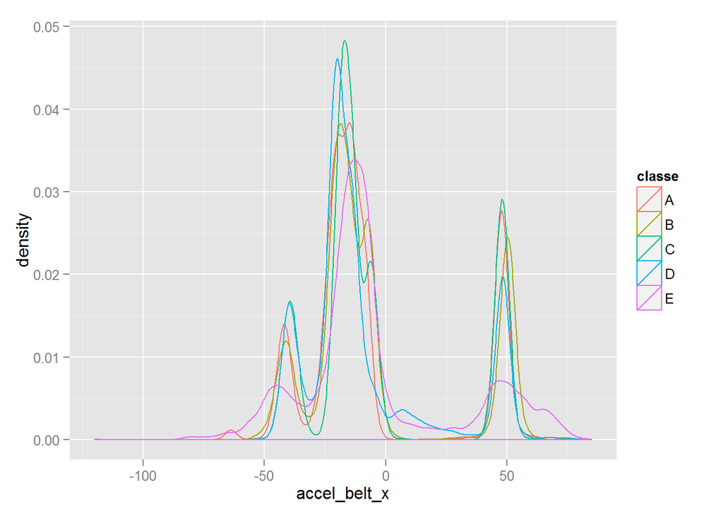

```r
qplot(accel_belt_x, colour = classe, data=training_sub, geom = "density")
```

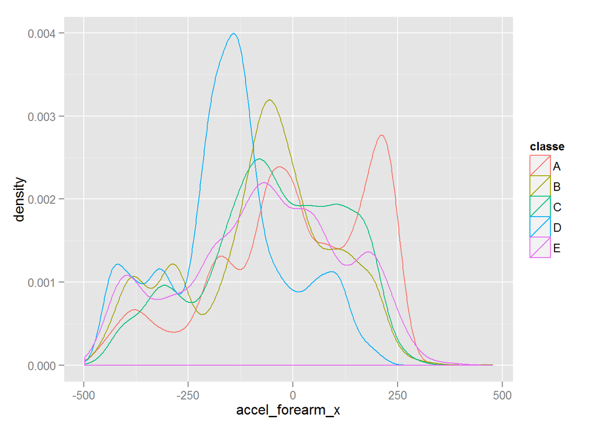

```r
qplot(accel_forearm_x, colour = classe, data=training_sub, geom = "density")
```

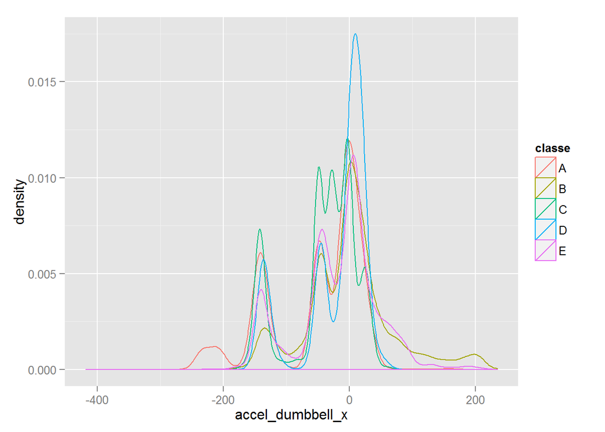

```r
qplot(accel_dumbbell_x, colour = classe, data=training_sub, geom = "density")
```

```r
#do graphs
```